# 49 [부록 2] 선별 아이템의 유형화

2014.16

2016.13

2020.46

1.09

0.95

0

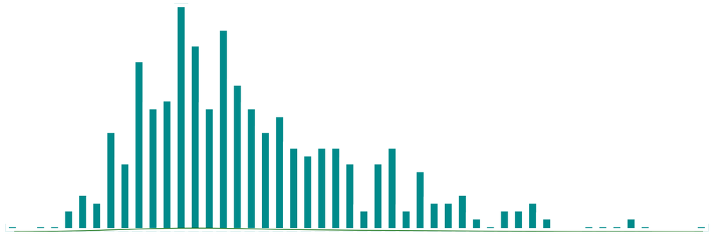

연평균복합성장률(규모)  
cagr_pub

3.83

14.24

58.27

9.94

1.74

0

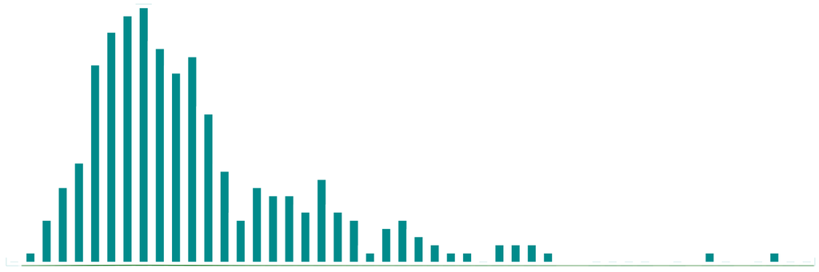

연평균복합성장률(확산)  
cagr_diffu

15.85

29.78

101.47

10.88

2.68

0

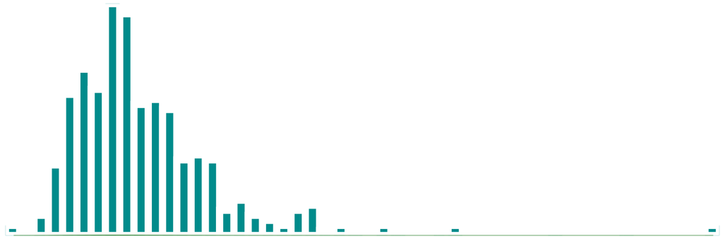

융합성 (15)

Rao-Stirling 다양성 지수(WoS분류)  
rs_div_wcate_17_21

0.14

0.51

0.75

0.12

-0.55

0

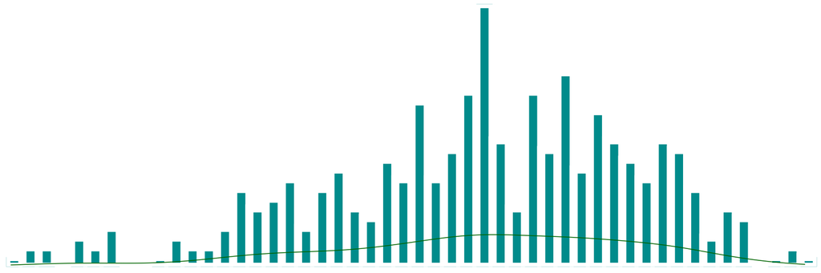

Rao-Stirling 다양성 지수(Citation Topics)  
rs_div_ct_17_21

0.05

0.53

0.82

0.16

-0.4

0

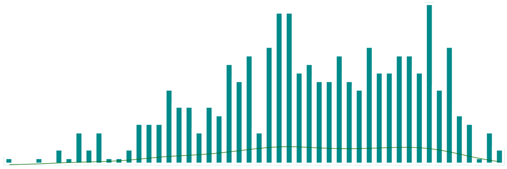

클러스터 지식흐름의 사이중앙성  
centrality_btwn

0

5924

167390.5

21767.49

3.21

0

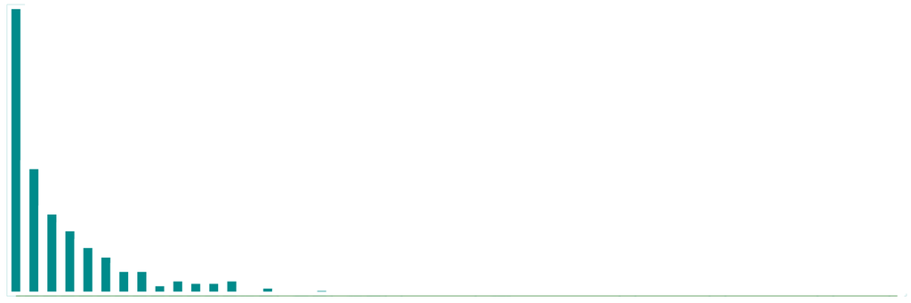

영향력 (10)

클러스터 단위 엑셀런스(2016-2018년)  
excellence_pp10_1618

3.48

16.07

66.77

9.53

1.59

0

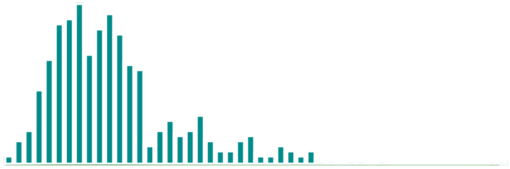

클러스터 단위 엑셀런스(2019-2021년)  
excellence_pp10_1921

2.58

14.19

58.59

7.91

1.24

0

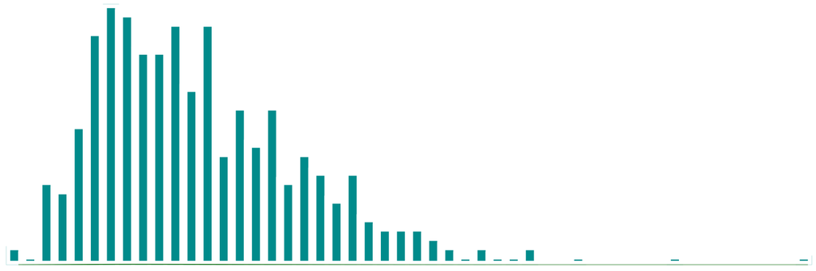

산업연계 (20)

산업활용성(2006-2021년)  
prop_cited_by_pat_06_21

0.24

13.48

46.61

7.29

0.48

0

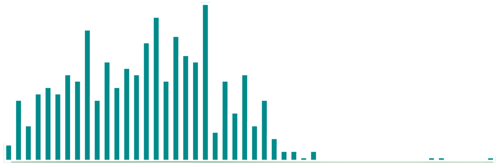

산업활용성(2017-2021년)  
prop_cited_by_pat_17_21

0.16

7.86

33.4

4.93

0.89

0

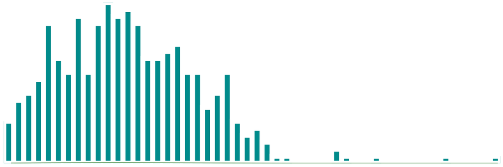

산업기반성(2006-2021년)  
prop_citting_pat_06_21

0.01

3.02

72.72

8.23

3.81

0

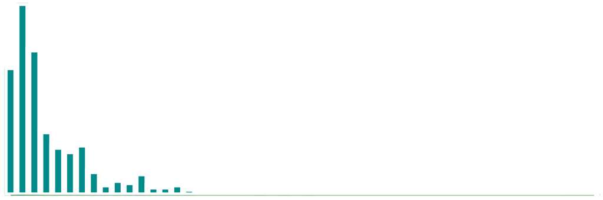

산업기반성(2017-2021년)  
prop_citting_pat_17_21

0.02

1.77

15.38

2.54

1.72

0

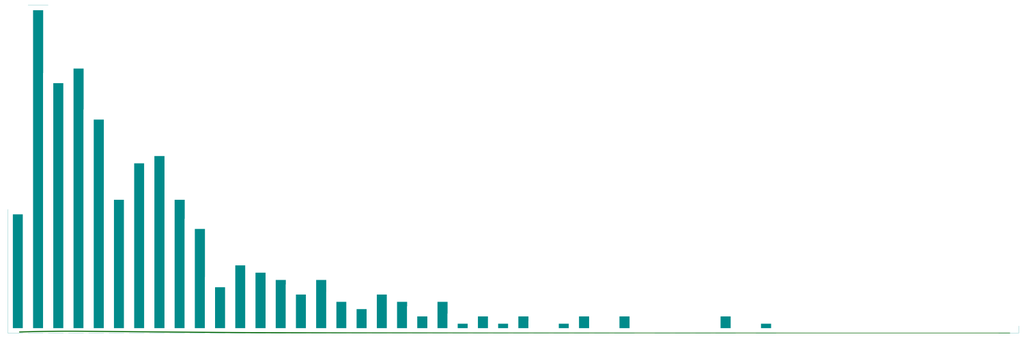

투자기반 (10)

한국 투자규모(2017-2021년)  
fund_total_bwon

1.09

125.1

979.75

178.82

1.78

0

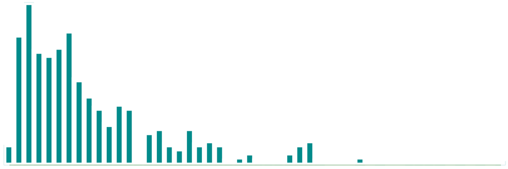

한국 투자 과제수(2017-2021년)  
n_projects

5

173

4141

439.83

4.76

0

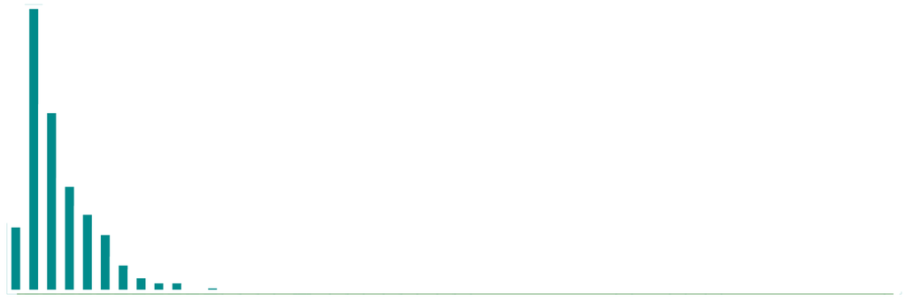

한국수준 (20)

한국 점유율(2006-2021년)  
kr_share_06_21

0.7

4.73

24.61

2.93

1.68

0

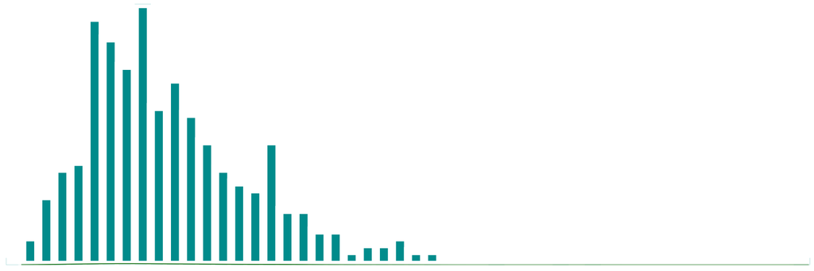

한국 점유율(2017-2021년)  
kr_share_17_21

0.48

4.8

21.47

2.71

1.39

0

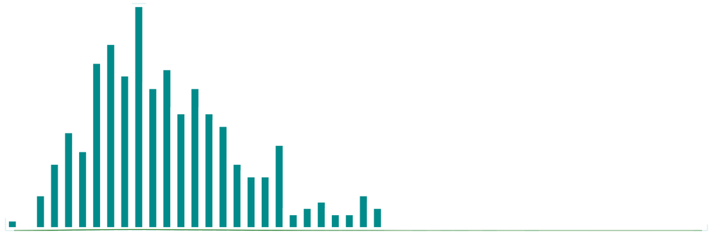

한국 엑셀런스(2016-2018년)  
kr_excel_pp10_1618

0

13.04

71.67

11.52

1.52

0

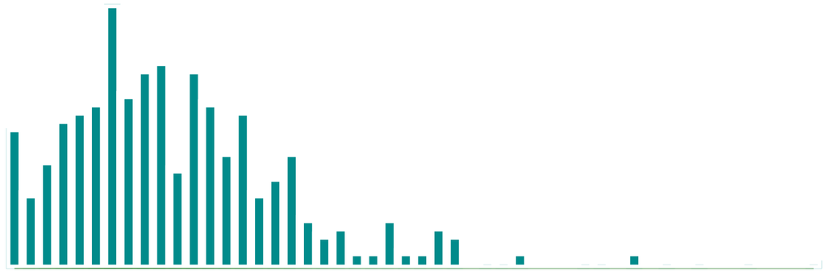

한국 엑셀런스(2019-2021년)  
kr_excel_pp10_1921

0

12.91

60

10.27

1.24

0

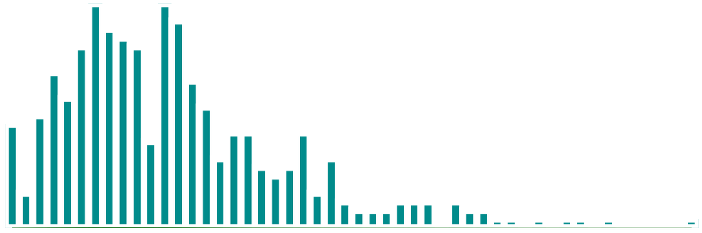

### 49.2.1 선별아이템의 지표 점수 분포 비교

[figure not shown]

그림 49.2: 전체 클러스터의 지표값 합산 총점 분포

표 49.3: 전체 클러스터와 선별 아이템의 지표값 총점 분포 비교

| 항목 | 최소값 | 제1사분위값 | 중앙값 | 평균 | 제3사분위값 | 최대값 |
| --- | --- | --- | --- | --- | --- | --- |
| 전체 (4,215개) | 0.00 | 20.00 | 32.00 | 36.55 | 50.00 | 111.00 |
| 선별 (371개) | 72.00 | 76.00 | 82.00 | 83.13 | 88.00 | 111.00 |

- 표 49.3 는 라이덴 클러스터 전체 4,215개, 선별 아이템 371개 집합 각각에 대해 22개 지표합산 총점의 주요 분포 값을 나타냄.

## 49.3 선별 아이템의 유형화 작업

### 49.3.1 유사성 기반 분류

- 라이덴 클러스터는 문헌 간 인용관계로 형성된 ‘연관성(relatedness)’ 정보를 바탕으로 클러스터링한 결과임.
- 선별된 371개 클러스터의 재클러스터링(re-clustering)을 위해 ‘문헌 간’ 인용관계를 ‘클러스터 간’ 인용관계로 변환하고 이를 적용
  - 논문 간 인용에서 참고문헌 수를 고려한 정규화를 적용하였듯이, 클러스터 간 인용에서도 참고문헌과 매칭된 클러스터의 갯수를 고려(즉, 개별 논문 단위에서 발생한 인용 링크의 합이 1이 되도록 조정)
  - 재클러스터링에 적용한 기법은 ‘Leiden Algorithm’[^2]이며, 세분화도(resolution) 인자를 조정하여 최적의 결과 도출

<sup>2</sup> [`igraph`패키지](https://r.igraph.org/)에 탑재한 모듈을 이용하였음.

- 1차 재클러스터링으로 371개 아이템을 41개 Meso로 묶고, 또다시 41개 Meso 영역 간의 링크관계를 구성한 뒤 2차 재클러스터링을 수행하여 최종 3개 Macro 영역을 도출
  - Meso 단위 영역 간의 매핑은 본 데이터북의 1.2 미래유망 융합기술 매핑 으로 확인 가능 (Macro 영역은 색상으로 구분)
  - Meso, Macro 구분은 본 4PN 데이터북의 목차 구성에 직접 활용
  - Meso 영역과 Macro 영역에 대한 명칭과 개요 부분은 기 도출된 개별 클러스터 명칭 및 내용 보고서를 기반으로 Claude 사의 LLM 모델(3.5 Sonnet)을 활용하여 생성

### 49.3.2 지표 기반 분류

- 선별 아이템들이 계량 지표적 특성을 유형화하기 위해 다음과 같은 절차를 수행
  - (1) 6개 유형으로 지표값 통합: 22개 지표의 등급 점수를 6개 유형별로 합산하고, 유형 간 비교가 용이하도록 유형별 최대 100점이 되도록 조정[^3]
  - (2) 계층적 클러스터링(Hierarchical Clustering): 6개 유형별 조정값들을 아이템의 특성(feature) 프로파일로 설정하고, WARD 방식으로 계층적 군집화 수행
  - (3) 계량특성 기준 5대 그룹 도출: 계층적 군집화 결과에서 5대 그룹을 결정하고(그림 49.3 참조), 그룹별로 각 6개 지표유형의 중심점(centroid)으로 5대 그룹 유형을 파악할 수 있는 레이더 차트 생성

<sup>3</sup> 6개 지표 유형별로 아이템들의 가능한 최대값을 100점으로 설정하고 실제 아이템들의 값을 조정

[figure not shown]

그림 49.3: 계층적 군집화결과에서 5개 유형(그룹)의 선택

- 각 5대 그룹의 중심점(centroid) 값들은 표 49.4 에서 확인할 수 있음. 선별된 아이템들은 전반적으로 융합성 유형 지표값들의 대역이 다른 유형 지표값에 비해 높지 않음을 확인할 수 있음.

표 49.4: 5대 그룹별로 6개 지표의 중심점(centroid) 비교

[output not shown]

[figure not shown]

그림 49.4: [그룹1 프론티어 연구] 레이더 차트

- 그룹1 프론티어 연구: 그림 49.4 와 같은 특성을 보임. 산업연계 관련 지표만 값만 전체 평균보다 낮고, 나머지 다른 유형의 지표값들이 평균을 훨씬 상회하는 값을 나타내어 현재 활발하게 연구되는 선도영역으로 볼 수 있음. 선별 아이템 371개 중 106개가 포함됨.

[figure not shown]

그림 49.5: [그룹2 첨단 산업(전략)] 레이더 차트

- 그룹2 첨단 산업(전략): 그림 49.5 와 같은 특성을 보임. 다이내믹스와 융합성 관련 지표가 전체 평균보다 다소 낮으나, 산업연계 관련 지표 값이 가장 높게 나타나며, 한국의 투자와 연구수준도 전체 평균을 웃돌아 국가 차원에서 전략적 대응을 하고 있는 영역으로 볼 수 있음. 선별 371개 아이템 중 가장 많은 123개가 속함.

[figure not shown]

그림 49.6: [그룹3 첨단 기반기술] 레이더 차트

- 그룹3 첨단 기반기술: 그림 49.6 와 같은 특성을 보임. 영향력 관련 지표는 전체 평균 대비 매우 낮게 나타나나 산업연계와 다이내믹스 관련 지표는 전체 평균을 상회함. 과학기술적 인용 파급력은 상대적으로 높지는 않지만 산업 영역에서 지속적으로 중요성이 확대되는 인프라성 기술로 볼 수 있음. 선별 371개 아이템 중 42개가 속함.

[figure not shown]

그림 49.7: [그룹4 다학제 연구] 레이더 차트

[figure not shown]

그림 49.8: [그룹5 첨단 산업(공백)] 레이더 차트

- 그룹5 첨단 산업(공백): 그림 49.8 와 같은 특성을 보임. 산업연계 관련 지표가 전체 평균을 크게 상회하고 영향력까지도 높은 기술이지만, 한국의 투자와 연구수준이 상대적으로 낮게 나타나 일종의 전략적 공백 기술이라고 볼 수 있음. 371개 전체 선별 아이템 중 48개가 속함.

### 49.3.3 지표기반 분류 테이블

표 49.5: 선별 아이템의 지표기반(100점 만점 환산) 분류 테이블

| cluster_id | 5대 그룹 | 아이템명 | meso_id | meso명 | 다이내믹스 | 융합성 | 영향력 | 산업연계성 | 투자기반성 | 한국수준 |
| --- | --- | --- | --- | --- | --- | --- | --- | --- | --- | --- |
| 3 | 그룹_1 | 코로나바이러스 감염 메커니즘 규명 및 효과적 치료법 개발을 위한 종합 연구 | 1 | 코로나바이러스 감염 메커니즘 및 환경 영향 연구와 대응 전략 개발 | 53.125 | 0 | 100 | 40 | 100 | 50 |
| 9 | 그룹_1 | 환경 친화적 나노복합체 흡착제를 이용한 수중 오염물질 제거 및 수처리 시스템 개발 | 2 | 지속가능한 수처리 및 환경오염 제어 | 84.375 | 0 | 100 | 45 | 100 | 40 |
| 18 | 그룹_2 | 나노구조 제어 및 복합화를 통한 고에너지밀도·고출력 슈퍼커패시터용 혁신 전극소재 기술 개발 | 3 | 차세대 고성능 에너지 저장 시스템 | 53.125 | 0 | 100 | 65 | 100 | 100 |
| 19 | 그룹_1 | 장내 미생물군집 조절을 통한 건강 증진 및 질병 예방 기술 개발 | 4 | 정밀의학 기반 질병 치료 및 건강 증진 | 100 | 20 | 100 | 50 | 100 | 50 |
| 27 | 그룹_1 | 친환경 고성능 시멘트계 재료의 개발 및 건설 산업에서의 혁신적 활용 기술 | 5 | 친환경 고성능 건설재료 및 지속가능한 건설 | 84.375 | 33.3333333333333 | 100 | 30 | 100 | 40 |
| 31 | 그룹_2 | 딥러닝 기반 의료영상 분석 및 진단 기술: 정확도 향상과 설명 가능한 AI를 위한 혁신적 접근 | 6 | 딥러닝 기반 지능형 컴퓨터 비전 및 하드웨어 가속 | 100 | 20 | 100 | 50 | 100 | 90 |
| 32 | 그룹_2 | 차세대 광촉매 소재 기반 고효율 물분해 수소 생산 및 환경 정화 융합 기술 개발 | 7 | 지속가능한 에너지 및 환경 | 37.5 | 20 | 100 | 50 | 100 | 80 |
| 43 | 그룹_2 | 차세대 고효율 페로브스카이트 태양전지 기술 개발 및 상용화를 위한 안정성 향상 연구 | 8 | 차세대 고성능 소재 및 소자 | 37.5 | 0 | 100 | 50 | 100 | 100 |
| 55 | 그룹_3 | 인공지능 기반 자연어 이해 및 생성을 위한 차세대 언어 모델 개발과 다양한 응용 분야 확장 기술 | 9 | 인공지능 기반 자연어 처리 및 정보 분석 | 84.375 | 0 | 60 | 40 | 100 | 50 |
| 68 | 그룹_1 | 불확실성과 제약조건을 고려한 비선형 시스템의 지능형 적응 제어 기술 개발 | 10 | 지능형 자율 시스템 제어 및 최적화 | 62.5 | 0 | 100 | 15 | 100 | 70 |

[output cut: 361 more lines]